# Practical Machine Learning - Course Project

Chua Yuanwei

## Introduction

The goal of the project is to quantify the quality of barbell bicep curls done by 6 participants, using data from accelerometers on the belt, forearm, arm, and dumbell of the participants. The data for this project come from this source: http://groupware.les.inf.puc-rio.br/har.

There are five classifications of this exercise, one method is the correct form of the exercise while the other four are common mistakes: exactly according to the specification (Class A), throwing the elbows to the front (Class B), lifting the dumbbell only halfway (Class C), lowering the dumbbell only halfway (Class D) and throwing the hips to the front (Class E).

## Data Preprocessing

```r
library(caret)
```

```r
library(rpart)
library(rpart.plot)
library(randomForest)
```

### Loading the Data

The training data is available from: https://d396qusza40orc.cloudfront.net/predmachlearn/pml-training.csv

The test data is available from: https://d396qusza40orc.cloudfront.net/predmachlearn/pml-testing.csv

After downloading the data from the sources, the two csv files are read into two data frames.

```r
trainRaw <- read.csv("pml-training.csv")
testRaw <- read.csv("pml-testing.csv")
dim(trainRaw)
```

```
## [1] 19622   160
```

```r
dim(testRaw)
```

```
## [1]  20 160
```

The training data set contains 19622 observations of 160 variables, while the testing data set contains 20 observations of 160 variables. The “classe” variable in the training set is the label of the classifications.

### Cleaning Data

```r
trainRaw <- trainRaw[, colSums(is.na(trainRaw)) == 0]
testRaw <- testRaw[, colSums(is.na(testRaw)) == 0]
classe <- trainRaw$classe
trainRemove <- grepl("^X|timestamp|window", names(trainRaw))
trainRaw <- trainRaw[, !trainRemove]
trainCleaned <- trainRaw[, sapply(trainRaw, is.numeric)]
trainCleaned$classe <- classe
testRemove <- grepl("^X|timestamp|window", names(testRaw))
testRaw <- testRaw[, !testRemove]
testCleaned <- testRaw[, sapply(testRaw, is.numeric)]
```

To avoid the risk of overfitting, we next check for covariates that have virtually no variablility.

```r
nearZeroVar(trainCleaned, saveMetrics=TRUE)
```

```
##                      freqRatio percentUnique zeroVar   nzv
## roll_belt             1.101904     6.7781062   FALSE FALSE
## pitch_belt            1.036082     9.3772296   FALSE FALSE
## yaw_belt              1.058480     9.9734991   FALSE FALSE
## total_accel_belt      1.063160     0.1477933   FALSE FALSE
## gyros_belt_x          1.058651     0.7134849   FALSE FALSE
## gyros_belt_y          1.144000     0.3516461   FALSE FALSE
## gyros_belt_z          1.066214     0.8612782   FALSE FALSE
## accel_belt_x          1.055412     0.8357966   FALSE FALSE
## accel_belt_y          1.113725     0.7287738   FALSE FALSE
## accel_belt_z          1.078767     1.5237998   FALSE FALSE
## magnet_belt_x         1.090141     1.6664968   FALSE FALSE
## magnet_belt_y         1.099688     1.5187035   FALSE FALSE
## magnet_belt_z         1.006369     2.3290184   FALSE FALSE
## roll_arm             52.338462    13.5256345   FALSE FALSE
## pitch_arm            87.256410    15.7323412   FALSE FALSE
## yaw_arm              33.029126    14.6570176   FALSE FALSE
## total_accel_arm       1.024526     0.3363572   FALSE FALSE
## gyros_arm_x           1.015504     3.2769341   FALSE FALSE
## gyros_arm_y           1.454369     1.9162165   FALSE FALSE
## gyros_arm_z           1.110687     1.2638875   FALSE FALSE
## accel_arm_x           1.017341     3.9598410   FALSE FALSE
## accel_arm_y           1.140187     2.7367241   FALSE FALSE
## accel_arm_z           1.128000     4.0362858   FALSE FALSE
## magnet_arm_x          1.000000     6.8239731   FALSE FALSE
## magnet_arm_y          1.056818     4.4439914   FALSE FALSE
## magnet_arm_z          1.036364     6.4468454   FALSE FALSE
## roll_dumbbell         1.022388    84.2065029   FALSE FALSE
## pitch_dumbbell        2.277372    81.7449801   FALSE FALSE
## yaw_dumbbell          1.132231    83.4828254   FALSE FALSE
## total_accel_dumbbell  1.072634     0.2191418   FALSE FALSE
## gyros_dumbbell_x      1.003268     1.2282132   FALSE FALSE
## gyros_dumbbell_y      1.264957     1.4167771   FALSE FALSE
## gyros_dumbbell_z      1.060100     1.0498420   FALSE FALSE
## accel_dumbbell_x      1.018018     2.1659362   FALSE FALSE
## accel_dumbbell_y      1.053061     2.3748853   FALSE FALSE
## accel_dumbbell_z      1.133333     2.0894914   FALSE FALSE
## magnet_dumbbell_x     1.098266     5.7486495   FALSE FALSE
## magnet_dumbbell_y     1.197740     4.3012945   FALSE FALSE
## magnet_dumbbell_z     1.020833     3.4451126   FALSE FALSE
## roll_forearm         11.589286    11.0895933   FALSE FALSE
## pitch_forearm        65.983051    14.8557741   FALSE FALSE
## yaw_forearm          15.322835    10.1467740   FALSE FALSE
## total_accel_forearm   1.128928     0.3567424   FALSE FALSE
## gyros_forearm_x       1.059273     1.5187035   FALSE FALSE
## gyros_forearm_y       1.036554     3.7763735   FALSE FALSE
## gyros_forearm_z       1.122917     1.5645704   FALSE FALSE
## accel_forearm_x       1.126437     4.0464784   FALSE FALSE
## accel_forearm_y       1.059406     5.1116094   FALSE FALSE
## accel_forearm_z       1.006250     2.9558659   FALSE FALSE
## magnet_forearm_x      1.012346     7.7667924   FALSE FALSE
## magnet_forearm_y      1.246914     9.5403119   FALSE FALSE
## magnet_forearm_z      1.000000     8.5771073   FALSE FALSE
## classe                1.469581     0.0254816   FALSE FALSE
```

Given that all of the near zero variance variables (nzv) are FALSE, there’s no need to eliminate any covariates due to lack of variablility.

### Slicing the Training Data

There are 19,622 observations in the training set, so in order to reduce time and to be able to perform cross-validation, a training subset is created with 60% of the original training data set to be used for training and the remaining 40% to be used as the testing set (before final testing is performed).

```r
set.seed(22519) # For reproducibile purpose
inTrain <- createDataPartition(y=trainCleaned$classe, p=0.6, list=FALSE)
trainData <- trainCleaned[inTrain, ]; testData <- trainCleaned[-inTrain, ]
dim(trainData); dim(testData)
```

```
## [1] 11776    53
```

```
## [1] 7846   53
```

## Tree-Based Models for Prediction

Two tree-based models, rpart and random forest, are built and their performances compared.

### rpart Model

As the outcomes are categorical (nominal), a decision tree is built using the method rpart.

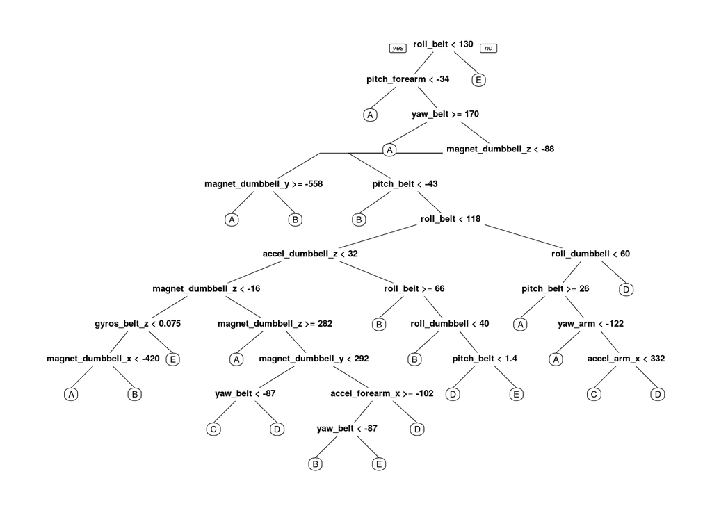

```r
rpartTree <- rpart(classe ~ ., data=trainData, method="class")
prp(rpartTree)
```

```r
predictRPart <- predict(rpartTree, testData, type = "class")
confusionMatrix(predictRPart, testData$classe)
```

```
## Confusion Matrix and Statistics
##
##           Reference
## Prediction    A    B    C    D    E
##          A 2005  344   60  129   30
##          B   57 1000  158  124  111
##          C   78   87 1077  263   89
##          D   47   29   66  739   89
##          E   45   58    7   31 1123
##
## Overall Statistics
##
##                Accuracy : 0.7576
##                  95% CI : (0.7479, 0.767)
##     No Information Rate : 0.2845
##     P-Value [Acc > NIR] : < 2.2e-16
##
##                   Kappa : 0.6915
##  Mcnemar's Test P-Value : < 2.2e-16
##
## Statistics by Class:
##
##                      Class: A Class: B Class: C Class: D Class: E
## Sensitivity            0.8983   0.6588   0.7873  0.57465   0.7788
## Specificity            0.8997   0.9289   0.9202  0.96479   0.9780
## Pos Pred Value         0.7808   0.6897   0.6757  0.76186   0.8884
## Neg Pred Value         0.9570   0.9190   0.9535  0.92045   0.9515
## Prevalence             0.2845   0.1935   0.1744  0.16391   0.1838
## Detection Rate         0.2555   0.1275   0.1373  0.09419   0.1431
## Detection Prevalence   0.3273   0.1848   0.2032  0.12363   0.1611
## Balanced Accuracy      0.8990   0.7938   0.8537  0.76972   0.8784
```

```r
accuracy <- postResample(predictRPart, testData$classe)
accuracy
```

```
##  Accuracy     Kappa
## 0.7575835 0.6915196
```

```r
oose <- 1 - as.numeric(confusionMatrix(testData$classe, predictRPart)$overall[1])
oose
```

```
## [1] 0.2424165
```

The estimated accuracy of the rpart model is 75.76% and the estimated out-of-sample error is 24.24%.

### Random Forests Model

```r
rfTree <- randomForest(classe ~. , data=trainData)
predictRF <- predict(rfTree, testData, type = "class")
confusionMatrix(predictRF, testData$classe)
```

```
## Confusion Matrix and Statistics
##
##           Reference
## Prediction    A    B    C    D    E
##          A 2232   14    0    0    0
##          B    0 1499    9    0    0
##          C    0    5 1359   14    0
##          D    0    0    0 1270    4
##          E    0    0    0    2 1438
##
## Overall Statistics
##
##                Accuracy : 0.9939
##                  95% CI : (0.9919, 0.9955)
##     No Information Rate : 0.2845
##     P-Value [Acc > NIR] : < 2.2e-16
##
##                   Kappa : 0.9923
##  Mcnemar's Test P-Value : NA
##
## Statistics by Class:
##
##                      Class: A Class: B Class: C Class: D Class: E
## Sensitivity            1.0000   0.9875   0.9934   0.9876   0.9972
## Specificity            0.9975   0.9986   0.9971   0.9994   0.9997
## Pos Pred Value         0.9938   0.9940   0.9862   0.9969   0.9986
## Neg Pred Value         1.0000   0.9970   0.9986   0.9976   0.9994
## Prevalence             0.2845   0.1935   0.1744   0.1639   0.1838
## Detection Rate         0.2845   0.1911   0.1732   0.1619   0.1833
## Detection Prevalence   0.2863   0.1922   0.1756   0.1624   0.1835
## Balanced Accuracy      0.9988   0.9930   0.9952   0.9935   0.9985
```

```r
accuracy <- postResample(predictRF, testData$classe)
accuracy
```

```
##  Accuracy     Kappa
## 0.9938822 0.9922600
```

```r
oose <- 1 - as.numeric(confusionMatrix(testData$classe, predictRF)$overall[1])
oose
```

```
## [1] 0.006117767
```

The estimated accuracy of the Random Forests model is 99.39% and the estimated out-of-sample error is 0.61%.

As expected, Random Forests yielded better results. That is because it generates a large number of bootstrapped trees (based on random samples of variables) and then classifies a case for each tree in this new “forest”. A final predicted outcome is decided by combining the results across all of the trees.

## Predicting for Test Data Set

Since Random Forests is a better predictor, we apply the model to the original testing data set downloaded from the data source.

```r
result <- predict(rfTree, testCleaned, type = "class")
result
```

```
##  1  2  3  4  5  6  7  8  9 10 11 12 13 14 15 16 17 18 19 20
##  B  A  B  A  A  E  D  B  A  A  B  C  B  A  E  E  A  B  B  B
## Levels: A B C D E
```